# chapter 2

2022-07-19

?? how to set working directory much more easier ??

```r
rm()
setwd("../data")
list.files()
```

```
##  [1] "chapter-2.docx"
##  [2] "chapter-2.Rmd"
##  [3] "chapter-2_cache"
##  [4] "chapter-2_files"
##  [5] "ELP_frequency.csv"
##  [6] "ELP_full_length_frequency.csv"
##  [7] "example_file.txt"
##  [8] "frequency_vowel_duration.csv"
##  [9] "hassemer_winter_2016_gesture.csv"
## [10] "lynott_connell_2009_modality.csv"
## [11] "mydataframe.RData"
## [12] "nettle.png"
## [13] "nettle_1999_climate.csv"
## [14] "perry_winter_2017_iconicity.csv"
## [15] "ruth_page_selfies.csv"
## [16] "sidhu&pexman_2017_iconicity.csv"
## [17] "speech_errors.csv"
## [18] "strik_lievers_winter_2018_POS.csv"
## [19] "testdir"
## [20] "vinson_dale_2014_yelp.csv"
## [21] "warriner_2013_emotional_valence.csv"
## [22] "winter_2016_senses_valence.csv"
## [23] "winter_matlock_2013_similarity.csv"
## [24] "winter_matlock_unpublished_distance.csv"
```

```r
library(tidyverse)
library(tibble)
library(readr)
library(dplyr)
library(magrittr)
```

```r
library(ggplot2)
```

## tibble and readr package

```r
# read.csv() function: it shows factor vectors rather than chr vector. why?
nettle <- read.csv('nettle_1999_climate.csv')
nettle <- as_tibble(nettle)
nettle
```

| Country | Population | Area | MGS | Langs |
| --- | --- | --- | --- | --- |
| Algeria | 4.41 | 6.38 | 6.60 | 18 |
| Angola | 4.01 | 6.10 | 6.22 | 42 |
| Australia | 4.24 | 6.89 | 6.00 | 234 |
| Bangladesh | 5.07 | 5.16 | 7.40 | 37 |
| Benin | 3.69 | 5.05 | 7.14 | 52 |
| Bolivia | 3.88 | 6.04 | 6.92 | 38 |
| Botswana | 3.13 | 5.76 | 4.60 | 27 |
| Brazil | 5.19 | 6.93 | 9.71 | 209 |
| Burkina Faso | 3.97 | 5.44 | 5.17 | 75 |
| CAR | 3.50 | 5.79 | 8.08 | 94 |

[output cut: 64 more lines]

```r
# to use readr package. read_csv() runs faster than read.csv()
nettle <- read_csv('nettle_1999_climate.csv')
nettle
```

| Country | Population | Area | MGS | Langs |
| --- | --- | --- | --- | --- |
| Algeria | 4.41 | 6.38 | 6.60 | 18 |
| Angola | 4.01 | 6.10 | 6.22 | 42 |
| Australia | 4.24 | 6.89 | 6.00 | 234 |
| Bangladesh | 5.07 | 5.16 | 7.40 | 37 |
| Benin | 3.69 | 5.05 | 7.14 | 52 |
| Bolivia | 3.88 | 6.04 | 6.92 | 38 |
| Botswana | 3.13 | 5.76 | 4.60 | 27 |
| Brazil | 5.19 | 6.93 | 9.71 | 209 |
| Burkina Faso | 3.97 | 5.44 | 5.17 | 75 |
| CAR | 3.50 | 5.79 | 8.08 | 94 |

[output cut: 64 more lines]

# delim argument specifies the type of separator.

```r
# You can use this function with files are not comma-separated files (.csv)
x <- read_delim('example_file.txt', delim = '\t')
x
```

| amanda | jeannette | gerardo |
| --- | --- | --- |
| 3 | 1 | 2 |
| 4 | 5 | 6 |

In the book, the data presents int, not dbl why?

# filter() function filters “rows”.

# first argument: tibble, second argument: logical statement

```r
# reduces the nettlb tibble to only those rows with countries that have more than 500 languages
filter(nettle, Langs > 500)
```

| Country | Population | Area | MGS | Langs |
| --- | --- | --- | --- | --- |
| Indonesia | 5.27 | 6.28 | 10.67 | 701 |
| Papua New Guinea | 3.58 | 5.67 | 10.88 | 862 |

```r
# may be interested in the data for a specific row, such as Nepal:
filter(nettle, Country == 'Nepal')
```

| Country | Population | Area | MGS | Langs |
| --- | --- | --- | --- | --- |
| Nepal | 4.29 | 5.15 | 6.39 | 102 |

# select function: to select “columns”

```r
# to select Langs and Country columns
select (nettle, Langs, Country)
```

| Langs | Country |
| --- | --- |
| 18 | Algeria |
| 42 | Angola |
| 234 | Australia |
| 37 | Bangladesh |
| 52 | Benin |
| 38 | Bolivia |
| 27 | Botswana |
| 209 | Brazil |
| 75 | Burkina Faso |
| 94 | CAR |

[output cut: 64 more lines]

```r
# to remove certain column
select (nettle, -Country)
```

| Population | Area | MGS | Langs |
| --- | --- | --- | --- |
| 4.41 | 6.38 | 6.60 | 18 |
| 4.01 | 6.10 | 6.22 | 42 |
| 4.24 | 6.89 | 6.00 | 234 |
| 5.07 | 5.16 | 7.40 | 37 |
| 3.69 | 5.05 | 7.14 | 52 |
| 3.88 | 6.04 | 6.92 | 38 |
| 3.13 | 5.76 | 4.60 | 27 |
| 5.19 | 6.93 | 9.71 | 209 |
| 3.97 | 5.44 | 5.17 | 75 |
| 3.50 | 5.79 | 8.08 | 94 |

[output cut: 64 more lines]

```r
# to select consecutive columns
select(nettle, Area:Langs)
```

| Area | MGS | Langs |
| --- | --- | --- |
| 6.38 | 6.60 | 18 |
| 6.10 | 6.22 | 42 |
| 6.89 | 6.00 | 234 |
| 5.16 | 7.40 | 37 |
| 5.05 | 7.14 | 52 |
| 6.04 | 6.92 | 38 |
| 5.76 | 4.60 | 27 |
| 6.93 | 9.71 | 209 |
| 5.44 | 5.17 | 75 |
| 5.79 | 8.08 | 94 |

[output cut: 64 more lines]

# rename () function: to change the name of existing columns

```r
nettle <- rename(nettle, Pop = Population)
nettle
```

| Country | Pop | Area | MGS | Langs |
| --- | --- | --- | --- | --- |
| Algeria | 4.41 | 6.38 | 6.60 | 18 |
| Angola | 4.01 | 6.10 | 6.22 | 42 |
| Australia | 4.24 | 6.89 | 6.00 | 234 |
| Bangladesh | 5.07 | 5.16 | 7.40 | 37 |
| Benin | 3.69 | 5.05 | 7.14 | 52 |
| Bolivia | 3.88 | 6.04 | 6.92 | 38 |
| Botswana | 3.13 | 5.76 | 4.60 | 27 |
| Brazil | 5.19 | 6.93 | 9.71 | 209 |
| Burkina Faso | 3.97 | 5.44 | 5.17 | 75 |
| CAR | 3.50 | 5.79 | 8.08 | 94 |

[output cut: 64 more lines]

# mutate () function: to change the content of a tibble.

```r
# this command creates a new columns,
# which is specified to be the "Langs" column divided by 100

nettle <- mutate(nettle, Lang100 = Langs / 100)
nettle
```

| Country | Pop | Area | MGS | Langs | Lang100 |
| --- | --- | --- | --- | --- | --- |
| Algeria | 4.41 | 6.38 | 6.60 | 18 | 0.18 |
| Angola | 4.01 | 6.10 | 6.22 | 42 | 0.42 |
| Australia | 4.24 | 6.89 | 6.00 | 234 | 2.34 |
| Bangladesh | 5.07 | 5.16 | 7.40 | 37 | 0.37 |
| Benin | 3.69 | 5.05 | 7.14 | 52 | 0.52 |
| Bolivia | 3.88 | 6.04 | 6.92 | 38 | 0.38 |
| Botswana | 3.13 | 5.76 | 4.60 | 27 | 0.27 |
| Brazil | 5.19 | 6.93 | 9.71 | 209 | 2.09 |
| Burkina Faso | 3.97 | 5.44 | 5.17 | 75 | 0.75 |
| CAR | 3.50 | 5.79 | 8.08 | 94 | 0.94 |

[output cut: 64 more lines]

# arrange () function: to order tibble in ascending or descending order.

```r
# ascending (default)
arrange (nettle, Langs)
```

| Country | Pop | Area | MGS | Langs | Lang100 |
| --- | --- | --- | --- | --- | --- |
| Cuba | 4.03 | 5.04 | 7.46 | 1 | 0.01 |
| Madagascar | 4.06 | 5.77 | 7.33 | 4 | 0.04 |
| Yemen | 4.09 | 5.72 | 0.00 | 6 | 0.06 |
| Nicaragua | 3.60 | 5.11 | 8.13 | 7 | 0.07 |
| Sri Lanka | 4.24 | 4.82 | 9.59 | 7 | 0.07 |
| Mauritania | 3.31 | 6.01 | 0.75 | 8 | 0.08 |
| Oman | 3.19 | 5.33 | 0.00 | 8 | 0.08 |
| Saudi Arabia | 4.17 | 6.33 | 0.40 | 8 | 0.08 |
| Honduras | 3.72 | 5.05 | 8.54 | 9 | 0.09 |
| UAE | 3.21 | 4.92 | 0.83 | 9 | 0.09 |

[output cut: 64 more lines]

```r
# descending
arrange (nettle, desc(Langs))
```

| Country | Pop | Area | MGS | Langs | Lang100 |
| --- | --- | --- | --- | --- | --- |
| Papua New Guinea | 3.58 | 5.67 | 10.88 | 862 | 8.62 |
| Indonesia | 5.27 | 6.28 | 10.67 | 701 | 7.01 |
| Nigeria | 5.05 | 5.97 | 7.00 | 427 | 4.27 |
| India | 5.93 | 6.52 | 5.32 | 405 | 4.05 |
| Cameroon | 4.09 | 5.68 | 9.17 | 275 | 2.75 |
| Mexico | 4.94 | 6.29 | 5.84 | 243 | 2.43 |
| Australia | 4.24 | 6.89 | 6.00 | 234 | 2.34 |
| Zaire | 4.56 | 6.37 | 9.44 | 219 | 2.19 |
| Brazil | 5.19 | 6.93 | 9.71 | 209 | 2.09 |
| Philippines | 4.80 | 5.48 | 10.34 | 168 | 1.68 |

[output cut: 64 more lines]

## ggplot2 package

Nettle (1999) discusses that linguistic diversity is correlated with climate factors. The proposal is that countries with lower ecological risk have more different languages than countries with higher ecological risk.

Nettle (1999) measured ecological risk by ‘mean growing season’ (listed in the MSG column).

Langs = the number of languages MGS = the mean growing season

# create a point plot

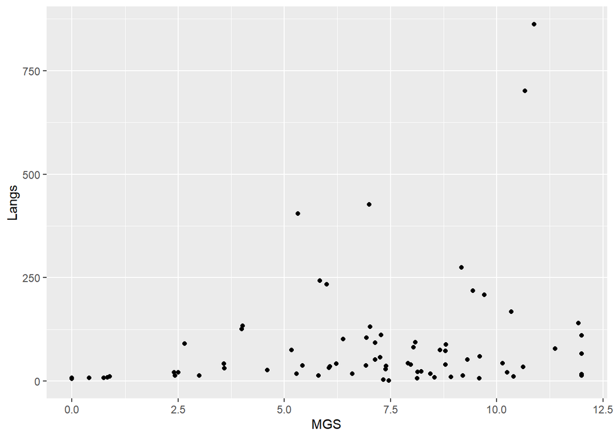

```r
# the first argument of ggplot() function: tibble
# geom_point () function adds a point geom to the plot
# aes() specifies the 'aesthetic mapping'
# ; which aspect of the data is mapped onto with aspect of the geom

# This code below specifies "aes" inside a geom

ggplot(nettle) +
  geom_point(mapping = aes (x = MGS, y = Langs))
```

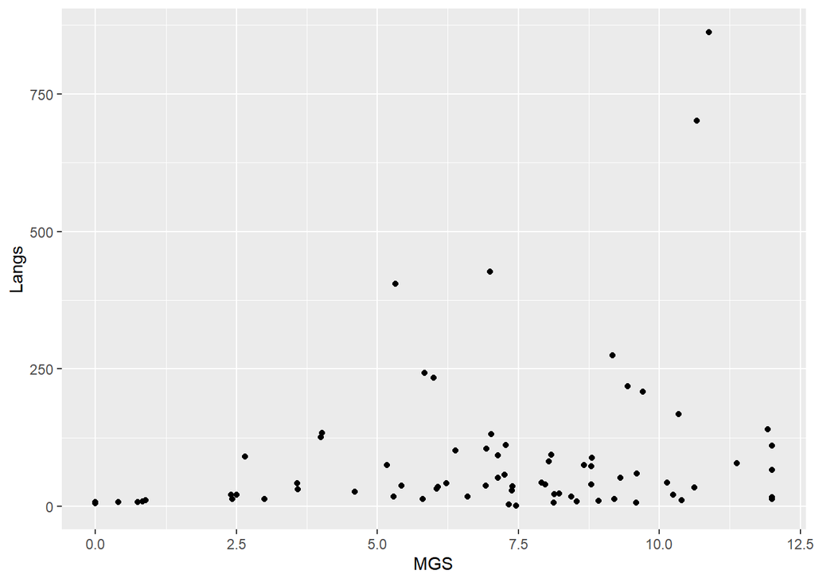

```r
# Paraphrased
# This code below specifies "aes" inside the main ggplot() function call.

ggplot(nettle, aes (x = MGS, y = Langs))+
  geom_point()
```

# create a text plot instead of points

ggplot(nettle, aes (x = MGS, y = Langs))+ geom_text()

````
```r
# ERROR showed!
# needs an additional aesthetic mapping
# which column is mapped to the actual text shown in the plot

ggplot(nettle, aes (x = MGS, y = Langs, label = Country))+
  geom_text()
````

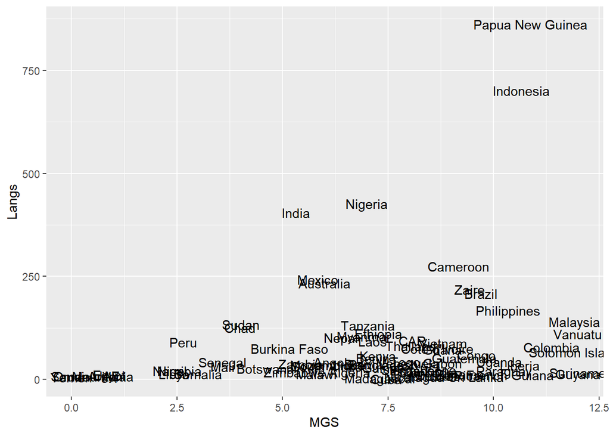

```r
ggsave('nettle.png')
# ggsave('nettle.png', width = 8, height = 6) occurs error unlike the result in
# the book
```

# gridExtra package: create the two plot aggrangement

```r
plot1 <- ggplot(nettle) +
  geom_point (mapping = aes (x = MGS, y = Langs))

plot2 <- ggplot (nettle,
                 aes (x = MGS, y = Langs, label = Country)) +
  geom_text()
```

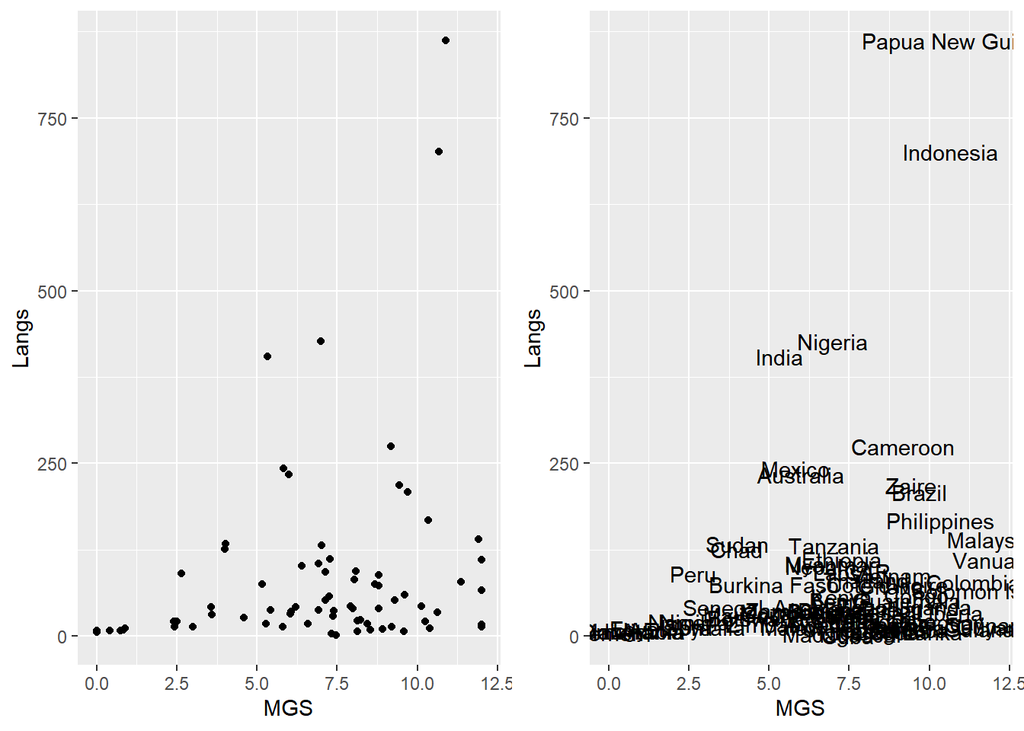

```r
# plot double plot:

# add this code
library(gridExtra) # error occurs
grid.arrange(plot1, plot2, ncol = 2)
```

## Piping with magrittr

pipe: %>% (shortcut: ctrl+shift+m)

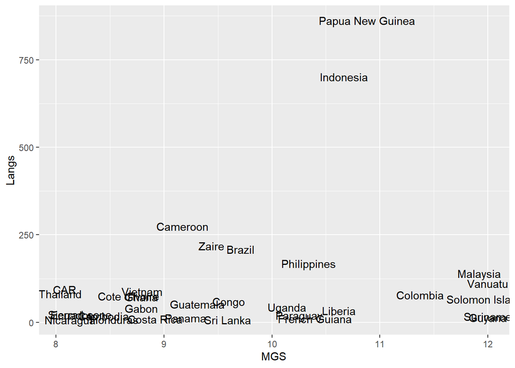

```r
nettle %>%
  filter(MGS > 8) %>%
  ggplot(aes(x = MGS, y = Langs, label = Country)) +
  geom_text()
```

## Iconicity and the Senses: a more extensive example

```r
icon <- read_csv('perry_winter_2017_iconicity.csv')
mod <- read_csv('lynott_connell_2009_modality.csv')
icon
```

| Word | POS | SER | CorteseImag | Conc | Syst | Freq | Iconicity |
| --- | --- | --- | --- | --- | --- | --- | --- |
| a | Grammatical | NA | NA | 1.46 | NA | 1041179 | 0.46153846 |
| abide | Verb | NA | NA | 1.68 | NA | 138 | 0.25000000 |
| able | Adjective | 1.73 | NA | 2.38 | NA | 8155 | 0.46666667 |
| about | Grammatical | 1.20 | NA | 1.77 | NA | 185206 | -0.10000000 |
| above | Grammatical | 2.91 | NA | 3.33 | NA | 2493 | 1.06250000 |
| abrasive | Adjective | NA | NA | 3.03 | NA | 23 | 1.31250000 |
| absorbent | Adjective | NA | NA | 3.10 | NA | 8 | 0.92307692 |
| academy | Noun | NA | NA | 4.29 | NA | 633 | 0.69230769 |
| accident | Noun | NA | NA | 3.26 | NA | 4146 | 1.36363636 |
| accordion | Noun | NA | NA | 4.86 | NA | 67 | -0.45454545 |

[output cut: 2991 more lines]

```r
mod
```

| PropertyBritish | Word | DominantModality | Sight | Touch | Sound | Taste | Smell | ModalityExclusivity |
| --- | --- | --- | --- | --- | --- | --- | --- | --- |
| abrasive | abrasive | Haptic | 2.8947368 | 3.68421053 | 1.68421053 | 0.57894737 | 0.57894737 | 0.3296089 |
| absorbent | absorbent | Visual | 4.1428571 | 3.14285714 | 0.71428571 | 0.47619048 | 0.47619048 | 0.4095745 |
| aching | aching | Haptic | 2.0476190 | 3.66666667 | 0.66666667 | 0.04761905 | 0.09523809 | 0.5547445 |
| acidic | acidic | Gustatory | 2.1904762 | 1.14285714 | 0.47619048 | 4.19047619 | 2.90476190 | 0.3406114 |
| acrid | acrid | Olfactory | 1.1250000 | 0.62500000 | 0.37500000 | 3.00000000 | 3.50000000 | 0.3623188 |
| adhesive | adhesive | Haptic | 3.6666667 | 4.33333333 | 1.19047619 | 0.90476190 | 1.76190476 | 0.2891566 |
| alcoholic | alcoholic | Gustatory | 2.8500000 | 0.35000000 | 0.75000000 | 4.35000000 | 4.30000000 | 0.3174603 |
| alive | alive | Visual | 4.5714286 | 3.80952381 | 4.09523810 | 1.57142857 | 2.38095238 | 0.1826087 |
| amber | amber | Visual | 4.4761905 | 0.52380952 | 0.14285714 | 0.57142857 | 0.85714286 | 0.6594203 |
| angular | angular | Visual | 4.2857143 | 4.09523810 | 0.25000000 | 0.04761905 | 0.04761905 | 0.4856753 |

[output cut: 413 more lines]

# Select columns

```r
icon <- select(icon, Word, POS, Iconicity)
icon
```

| Word | POS | Iconicity |
| --- | --- | --- |
| a | Grammatical | 0.46153846 |
| abide | Verb | 0.25000000 |
| able | Adjective | 0.46666667 |
| about | Grammatical | -0.10000000 |
| above | Grammatical | 1.06250000 |
| abrasive | Adjective | 1.31250000 |
| absorbent | Adjective | 0.92307692 |
| academy | Noun | 0.69230769 |
| accident | Noun | 1.36363636 |
| accordion | Noun | -0.45454545 |

[output cut: 2991 more lines]

The dataset contain 3001 words and their iconicity rating. POS: part-of-speech tags

Iconicity: the linguistic form evokes some properties of referent, as it is the case in onomatopoeic words (e.g., “boom”, “quack”)

Iconicity rating task: scale from -5 (‘the word sounds like the the opposite of what it means’) to +5 (‘the word sounds exactly like what it means’)

# range of scale

```r
range(icon$Iconicity)
```

```
## [1] -2.800000  4.466667
```

# Let’s draw histogram

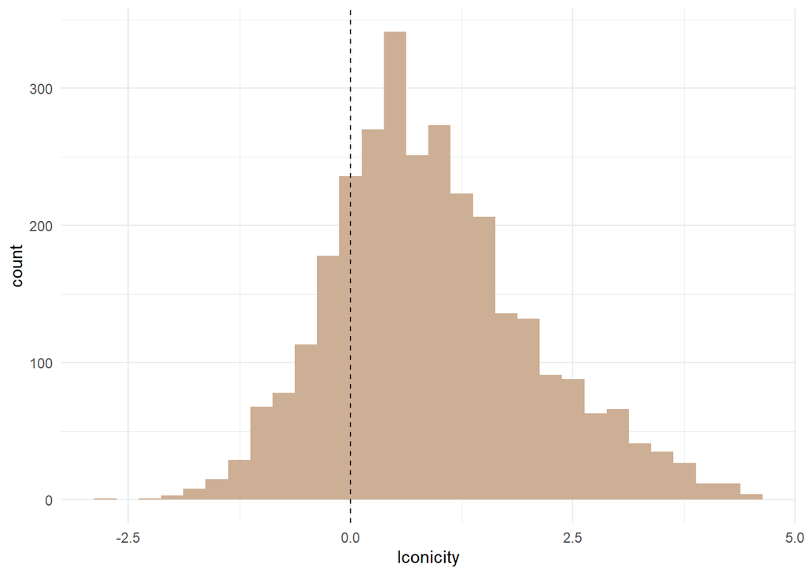

```r
ggplot(icon, aes(x = Iconicity)) +                              # x-values
  geom_histogram(fill = 'peachpuff3') +                         # fill = colour
  geom_vline(aes(xintercept = 0), linetype = 2) +
  theme_minimal()
```

# Extended version of tibble

```r
mod %>% print(n = Inf)
```

```
## # A tibble: 423 x 9
##     PropertyBritish Word      DominantModality Sight  Touch  Sound  Taste  Smell
##     <chr>           <chr>     <chr>            <dbl>  <dbl>  <dbl>  <dbl>  <dbl>
##   1 abrasive        abrasive  Haptic           2.89  3.68   1.68   0.579  0.579
##   2 absorbent       absorbent Visual           4.14  3.14   0.714  0.476  0.476
##   3 aching          aching    Haptic           2.05  3.67   0.667  0.0476 0.0952
##   4 acidic          acidic    Gustatory        2.19  1.14   0.476  4.19   2.90
##   5 acrid           acrid     Olfactory        1.12  0.625  0.375  3      3.5
##   6 adhesive        adhesive  Haptic           3.67  4.33   1.19   0.905  1.76
##   7 alcoholic       alcoholic Gustatory        2.85  0.35   0.75   4.35   4.3
##   8 alive           alive     Visual           4.57  3.81   4.10   1.57   2.38
##   9 amber           amber     Visual           4.48  0.524  0.143  0.571  0.857
##  10 angular         angular   Visual           4.29  4.10   0.25   0.0476 0.0476
##  11 antiseptic      antisept~ Olfactory        1.67  0.9    0.143  1.76   3.95
##  12 aromatic        aromatic  Olfactory        1.3   0.333  0.286  3.38   4.52
```

[output cut: 412 more lines]

# Select columns

```r
mod <- select(mod, Word, DominantModality:Smell)
mod
```

| Word | DominantModality | Sight | Touch | Sound | Taste | Smell |
| --- | --- | --- | --- | --- | --- | --- |
| abrasive | Haptic | 2.8947368 | 3.68421053 | 1.68421053 | 0.57894737 | 0.57894737 |
| absorbent | Visual | 4.1428571 | 3.14285714 | 0.71428571 | 0.47619048 | 0.47619048 |
| aching | Haptic | 2.0476190 | 3.66666667 | 0.66666667 | 0.04761905 | 0.09523809 |
| acidic | Gustatory | 2.1904762 | 1.14285714 | 0.47619048 | 4.19047619 | 2.90476190 |
| acrid | Olfactory | 1.1250000 | 0.62500000 | 0.37500000 | 3.00000000 | 3.50000000 |
| adhesive | Haptic | 3.6666667 | 4.33333333 | 1.19047619 | 0.90476190 | 1.76190476 |
| alcoholic | Gustatory | 2.8500000 | 0.35000000 | 0.75000000 | 4.35000000 | 4.30000000 |
| alive | Visual | 4.5714286 | 3.80952381 | 4.09523810 | 1.57142857 | 2.38095238 |
| amber | Visual | 4.4761905 | 0.52380952 | 0.14285714 | 0.57142857 | 0.85714286 |
| angular | Visual | 4.2857143 | 4.09523810 | 0.25000000 | 0.04761905 | 0.04761905 |

[output cut: 413 more lines]

# Rename a column

```r
mod <- rename(mod, Modality = DominantModality)
mod
```

| Word | Modality | Sight | Touch | Sound | Taste | Smell |
| --- | --- | --- | --- | --- | --- | --- |
| abrasive | Haptic | 2.8947368 | 3.68421053 | 1.68421053 | 0.57894737 | 0.57894737 |
| absorbent | Visual | 4.1428571 | 3.14285714 | 0.71428571 | 0.47619048 | 0.47619048 |
| aching | Haptic | 2.0476190 | 3.66666667 | 0.66666667 | 0.04761905 | 0.09523809 |
| acidic | Gustatory | 2.1904762 | 1.14285714 | 0.47619048 | 4.19047619 | 2.90476190 |
| acrid | Olfactory | 1.1250000 | 0.62500000 | 0.37500000 | 3.00000000 | 3.50000000 |
| adhesive | Haptic | 3.6666667 | 4.33333333 | 1.19047619 | 0.90476190 | 1.76190476 |
| alcoholic | Gustatory | 2.8500000 | 0.35000000 | 0.75000000 | 4.35000000 | 4.30000000 |
| alive | Visual | 4.5714286 | 3.80952381 | 4.09523810 | 1.57142857 | 2.38095238 |
| amber | Visual | 4.4761905 | 0.52380952 | 0.14285714 | 0.57142857 | 0.85714286 |
| angular | Visual | 4.2857143 | 4.09523810 | 0.25000000 | 0.04761905 | 0.04761905 |

[output cut: 413 more lines]

# check random rows

```r
sample_n(mod, 4)
```

| Word | Modality | Sight | Touch | Sound | Taste | Smell |
| --- | --- | --- | --- | --- | --- | --- |
| mottled | Visual | 4.363636 | 1.333333 | 0.6363636 | 0.6363636 | 0.7272727 |
| sheer | Visual | 4.526316 | 2.894737 | 0.5789474 | 0.0000000 | 0.0000000 |
| curved | Visual | 4.500000 | 3.950000 | 0.1000000 | 0.1052632 | 0.0000000 |
| greasy | Haptic | 3.761905 | 3.952381 | 0.1904762 | 3.8095238 | 2.3333333 |

# merge two tibbles (joining by word)

```r
both <- left_join(icon, mod)
both
```

| Word | POS | Iconicity | Modality | Sight | Touch | Sound | Taste | Smell |
| --- | --- | --- | --- | --- | --- | --- | --- | --- |
| a | Grammatical | 0.46153846 | NA | NA | NA | NA | NA | NA |
| abide | Verb | 0.25000000 | NA | NA | NA | NA | NA | NA |
| able | Adjective | 0.46666667 | NA | NA | NA | NA | NA | NA |
| about | Grammatical | -0.10000000 | NA | NA | NA | NA | NA | NA |
| above | Grammatical | 1.06250000 | NA | NA | NA | NA | NA | NA |
| abrasive | Adjective | 1.31250000 | Haptic | 2.8947368 | 3.68421053 | 1.68421053 | 0.57894737 | 0.57894737 |
| absorbent | Adjective | 0.92307692 | Visual | 4.1428571 | 3.14285714 | 0.71428571 | 0.47619048 | 0.47619048 |
| academy | Noun | 0.69230769 | NA | NA | NA | NA | NA | NA |
| accident | Noun | 1.36363636 | NA | NA | NA | NA | NA | NA |
| accordion | Noun | -0.45454545 | NA | NA | NA | NA | NA | NA |

[output cut: 2991 more lines]

# Let’s filter the dataset including adjectives, verbs, and nouns

%in% function need two vectors to compare, and check whether the elecments of the second vector are matched in the first vector.

The result is logical statement.

```r
both <- filter (both,
                POS %in% c('Adjective', 'Verb', 'Noun'))
both
```

| Word | POS | Iconicity | Modality | Sight | Touch | Sound | Taste | Smell |
| --- | --- | --- | --- | --- | --- | --- | --- | --- |
| abide | Verb | 0.25000000 | NA | NA | NA | NA | NA | NA |
| able | Adjective | 0.46666667 | NA | NA | NA | NA | NA | NA |
| abrasive | Adjective | 1.31250000 | Haptic | 2.8947368 | 3.68421053 | 1.68421053 | 0.57894737 | 0.57894737 |
| absorbent | Adjective | 0.92307692 | Visual | 4.1428571 | 3.14285714 | 0.71428571 | 0.47619048 | 0.47619048 |
| academy | Noun | 0.69230769 | NA | NA | NA | NA | NA | NA |
| accident | Noun | 1.36363636 | NA | NA | NA | NA | NA | NA |
| accordion | Noun | -0.45454545 | NA | NA | NA | NA | NA | NA |
| account | Noun | -0.42857143 | NA | NA | NA | NA | NA | NA |
| ache | Noun | 1.15384615 | NA | NA | NA | NA | NA | NA |
| aching | Verb | 0.25000000 | Haptic | 2.0476190 | 3.66666667 | 0.66666667 | 0.04761905 | 0.09523809 |

[output cut: 2786 more lines]

# Let’s make a boxplot

*x-axis* = Modality *y-axis* = Iconicity *Modality* caterories onto the *fill* argument, which assigns each sensory modality a unique colour.

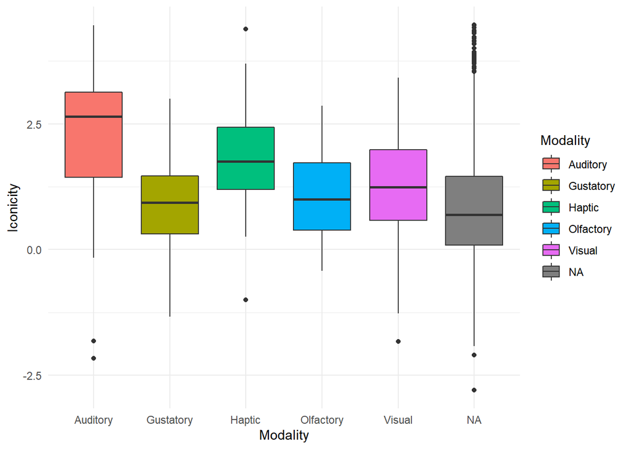

```r
ggplot(both,
       aes (x = Modality, y = Iconicity, fill = Modality)) +
  geom_boxplot() + theme_minimal()
```

- Gustatory: taste-related
- Haptic: touch-related
- Olfactory: smell-related

# Remove unnecessary data using filter

*is.na* function check if the value is NA (logical statement) *!* means negation.

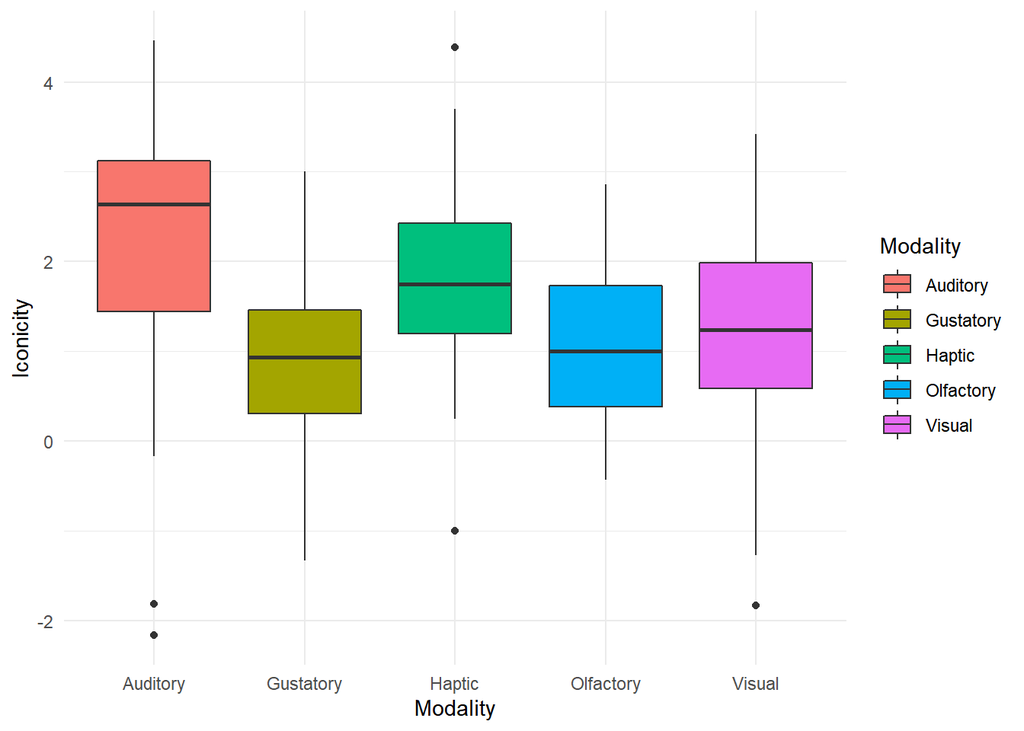

```r
both %>% filter(!is.na(Modality)) %>%
  ggplot(aes (x= Modality, y = Iconicity,
              fill = Modality)) +
  geom_boxplot() + theme_minimal()
```

# Have a look at the counts of words per sesory modality

```r
both %>% count(Modality)
```

| Modality | n |
| --- | --- |
| Auditory | 67 |
| Gustatory | 47 |
| Haptic | 67 |
| Olfactory | 24 |
| Visual | 202 |
| NA | 2389 |

# Exclude an NA row

```r
both %>% count(Modality) %>%
  filter(!is.na(Modality))
```

| Modality | n |
| --- | --- |
| Auditory | 67 |
| Gustatory | 47 |
| Haptic | 67 |
| Olfactory | 24 |
| Visual | 202 |

# Let’s make a bar plot.

- stat=“identity” : y축에 명시한 값을 기준으로 그래프로 표현

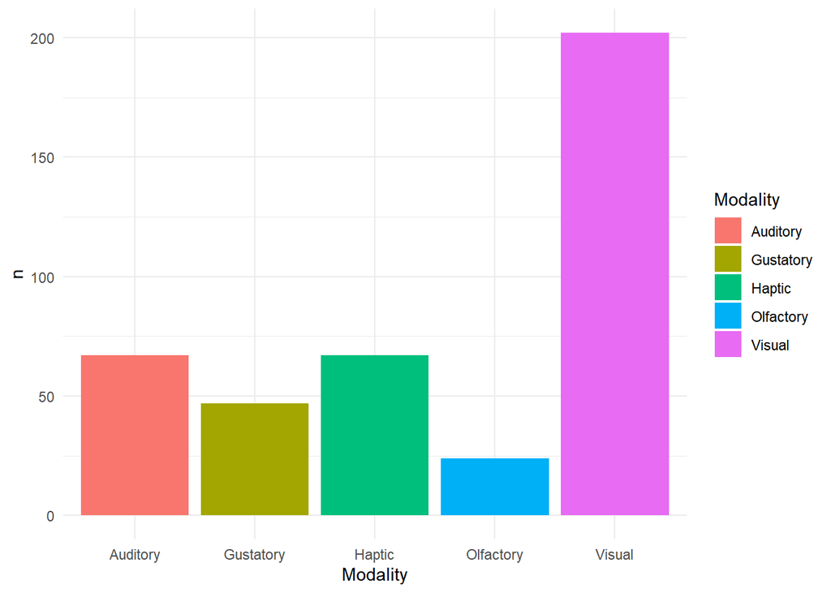

```r
both %>% count(Modality) %>%
  filter(!is.na(Modality)) %>%
  ggplot(aes(x = Modality, y = n, fill = Modality)) +              # n의 의미?
  geom_bar(stat = 'identity') + theme_minimal()
```

- stat = ’count’는 count에 명시된 값을 기준으로 그래프를 표현 - (aes 안에 y 축을 표시할 필요 없음)

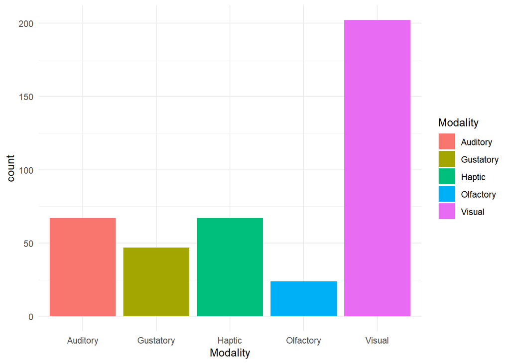

```r
both %>% filter(!is.na(Modality)) %>%
  ggplot(aes(Modality, fill = Modality)) +
  geom_bar(stat = 'count') + theme_minimal()
```

## How to use R markdown

```r
# R code goes in here
```

```r
# R code goes in here
```